# Social Interactions at a Public High School

Lauren Treiman

8/3/2018

This analysis was used to help an epidimeoly research project at the University of Utah investigate how interactions spread viruses such as the flu. This file contains the social network analysis for one high school in Salt Lake City. To obtain the data, students wore sensors that recorded how long and who a student interacted with. Students wore these sensors for two whole school days.

For this project, I used R-markdown to create the html document and used packages such as igraph, dplyr, chron, and lubridate.

# Summary of Network

There are two networks for each day of the experiment. There are 4 90 minute periods, 3 6 minute hallway passings, and 2 30 minute lunches.

Day 1

```
## IGRAPH 7e9b037 UN-- 1425 153999 --
## + attr: name (v/c), GradeCat (v/n), GenderCat (v/n), Lunch (v/n),
## | TotalSeconds (e/n), BeginDateTime (e/c), EndDateTime (e/c),
## | Duration (e/n), period (e/c)
```

For day 1, there were 1425 students who participated and 153999 interactions. Day 2

```
## IGRAPH a6224fa UN-- 1220 556935 --
## + attr: name (v/c), GradeCat (v/n), GenderCat (v/n), Lunch (v/n),
## | TotalSeconds (e/n), BeginDateTime (e/c), EndDateTime (e/c),
## | Duration (e/n), period (e/c)
```

For day 2, there were 1220 students who participated and 556935 interavtions.

# Distribution

I graphed the distribution of the number of interactions for each hallway, period and lunches, and after school. Both lunches are grouped together. Also, it is important to note that sensors were handed out to students in period 1, so there is an overestimate of total interactions for period 1.

Day 1

```
##  After School Hallway1 Hallway2 Hallway3 Lunch Period1 Period2 Period3 Period4
##
##         17765     2385     2592     2317 12951   49223   22944   21297   22525
```

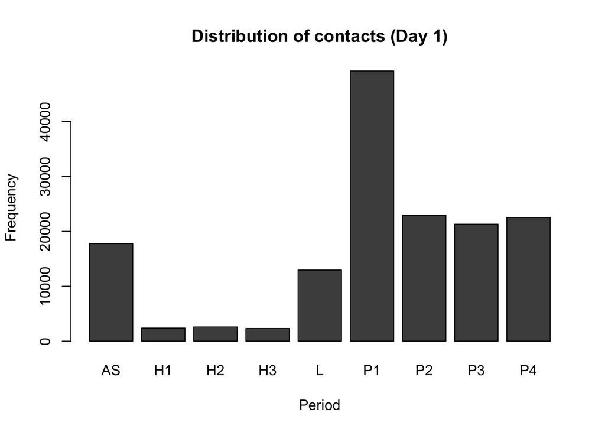

(AS = After School)

Day 2

[output not shown]

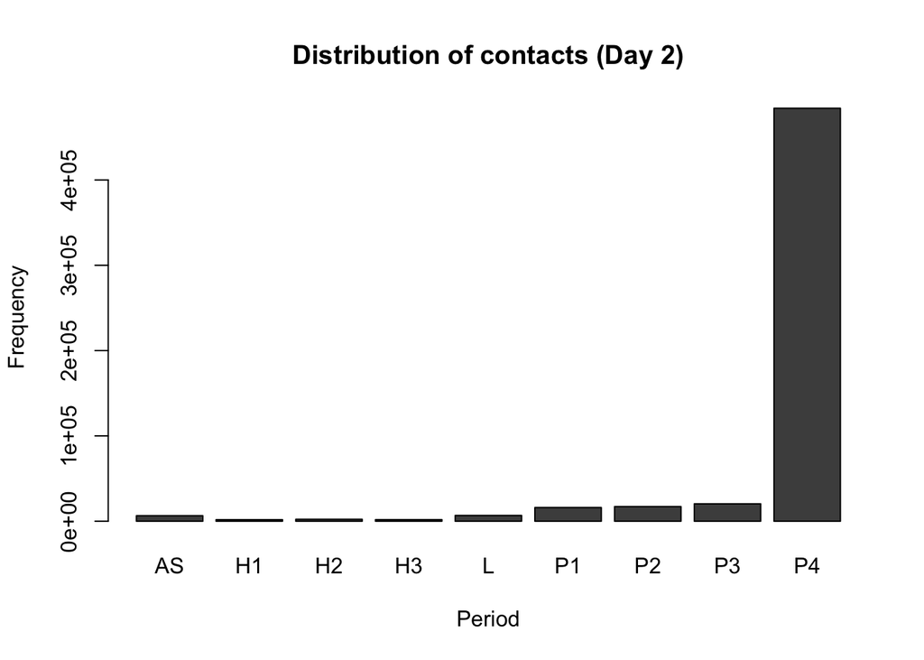

# Interactions Throughout the Day

The two plots show the new interactions as the day progresses. Day 1

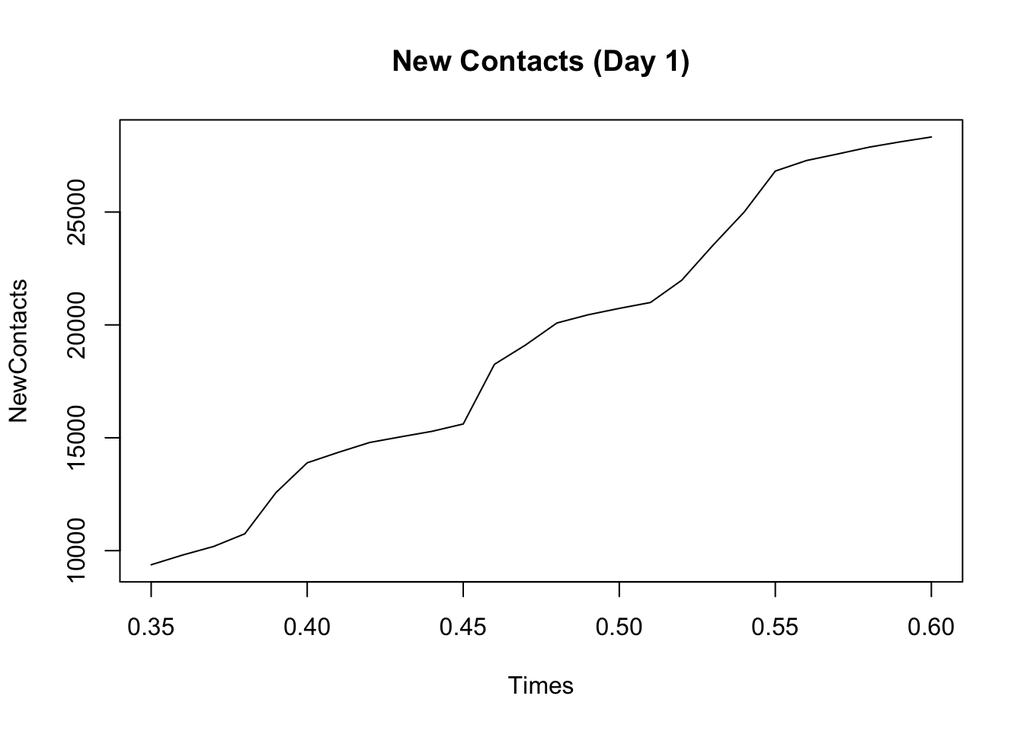

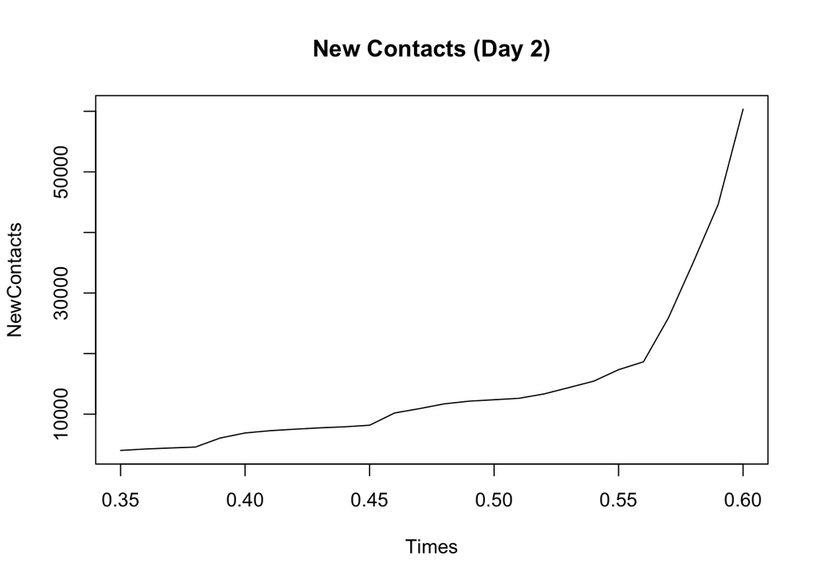

I then looked at different social networking attributes including degree, betweenness, closeness, transitivity, density and assortativity.

# Degree

Day 1

```
##        Measure Min  Q1 Median       Mean  Q3 Max
## 1      All day   2 136    207 216.138947 282 704
## 2  All periods   1  98    154 162.791579 215 500
## 3     Period 1   0  35     61  69.084912  97 307
## 4    Hallway 1   0   1      3   3.347368   5  30
## 5     Period 2   0  11     26  32.202105  46 185
## 6    Hallway 2   0   1      3   3.637895   5  32
## 7        Lunch   0   7     16  18.176842  26  98
## 8     Period 3   0   8     23  29.890526  45 159
## 9    Hallway 3   0   1      2   3.251930   5  20
## 10    Period 4   0   8     24  31.614035  46 182
```

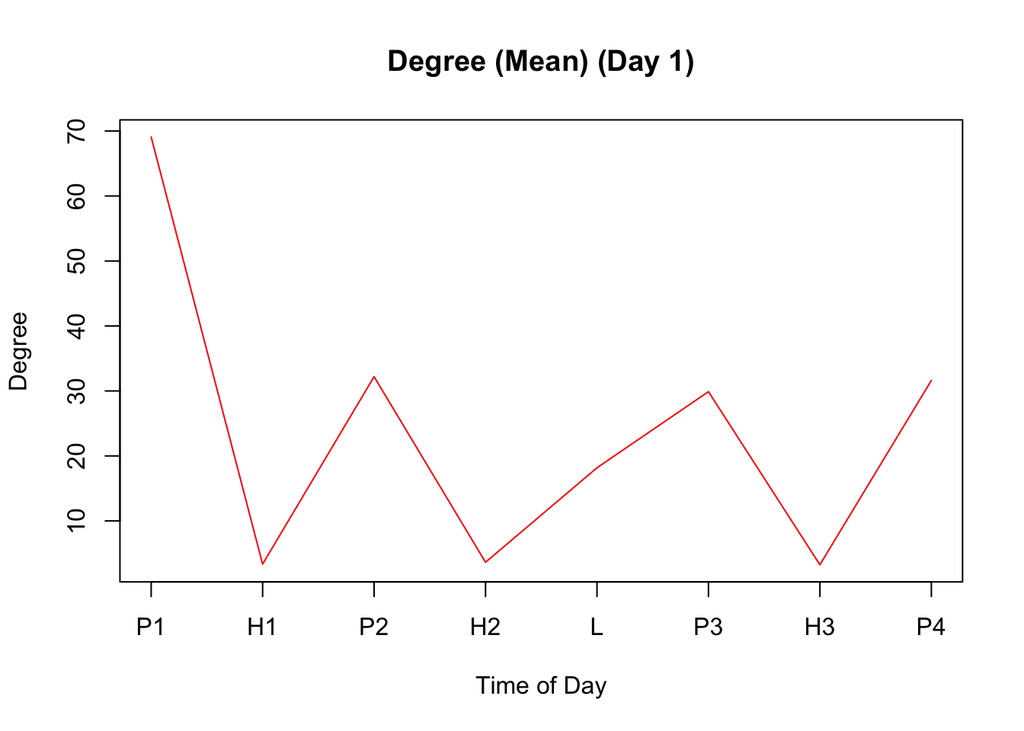

Day 2

```
##        Measure Min  Q1 Median       Mean     Q3  Max
## 1      All day   1 117    208 913.008197 523.50 5223
## 2  All periods   0 102    184 892.109836 481.75 5209
## 3     Period 1   0   5     18  26.311475  39.00  152
## 4    Hallway 1   0   1      2   2.985246   4.00   18
## 5     Period 2   0   7     22  28.167213  40.25  206
## 6    Hallway 2   0   1      3   3.719672   5.00   41
## 7        Lunch   0   3      8  11.139344  16.00   74
## 8     Period 3   0  13     27  33.509836  48.00  158
## 9    Hallway 3   0   1      2   3.054098   5.00   16
## 10    Period 4   0  19     50 793.554098 344.00 5151
```

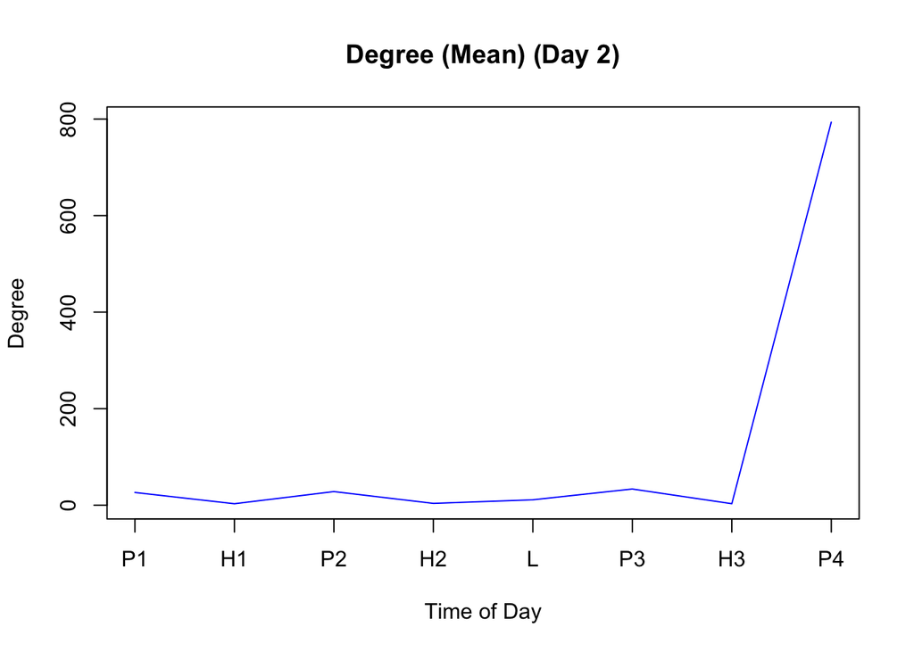

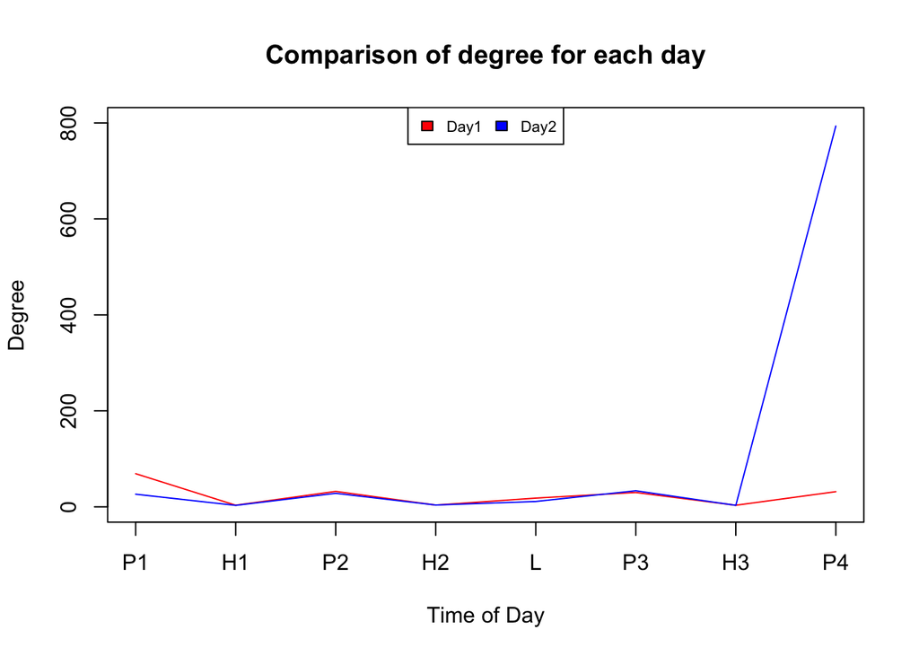

# Betweenness

Day 1

```
##        Measure       Min           Q1    Median      Mean        Q3
## 1      All day 0.1567588 334.93022869 772.89874  956.1979 1354.5604
## 2  All periods 0.0000000 437.95946877 916.32280 1203.0035 1708.0332
## 3     Period 1 0.0000000   1.86578144  63.36503 3461.3235  690.5111
## 4    Hallway 1 0.0000000   0.00000000 955.51833 2447.9186 3315.8083
## 5     Period 2 0.0000000   0.62557498 592.16790 4045.6393 3819.8502
## 6    Hallway 2 0.0000000   0.00000000 600.36704 2119.7972 2719.8638
## 7        Lunch 0.0000000 154.81162615 948.43728 1914.1972 2483.0749
## 8     Period 3 0.0000000   0.01320622 228.33839 4554.3060 2941.0047
## 9    Hallway 3 0.0000000   0.00000000 362.73761 1868.2112 2352.8285
## 10    Period 4 0.0000000   0.08803701 484.93794 3256.3832 3397.2198
##           Max
## 1    6683.899
## 2    9635.527
## 3  220261.761
## 4   39157.746
## 5   97654.775
## 6   43118.184
## 7   48022.364
## 8  130600.730
## 9   36580.794
## 10  99725.299
```

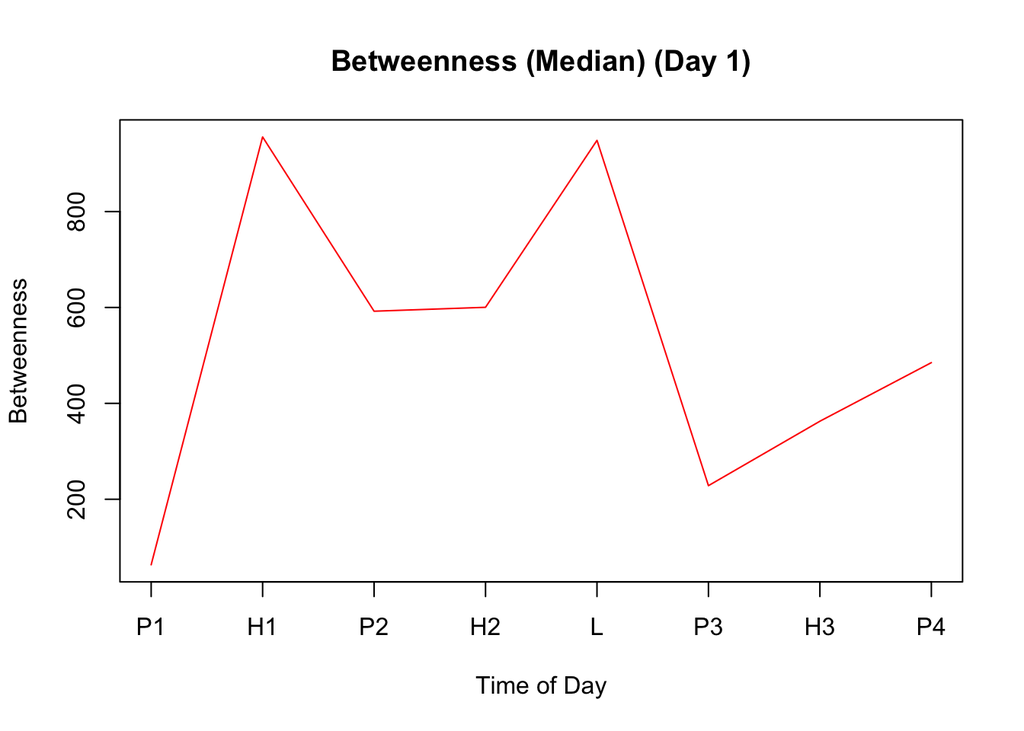

Day 2

```
##        Measure Min        Q1   Median      Mean        Q3       Max
## 1      All day   0 145.19109 369.3038  698.2984  909.9495  6178.156
## 2  All periods   0 142.07282 380.7294  736.4984  934.5057  6283.603
## 3     Period 1   0   0.00000 241.4009 2539.9492 2621.2555 94858.865
## 4    Hallway 1   0   0.00000 319.7882 1686.9025 2210.1744 32879.639
## 5     Period 2   0   0.00000 554.9565 2893.9148 3587.7324 55082.512
## 6    Hallway 2   0   0.00000 557.5593 1895.7697 2539.1902 26615.949
## 7        Lunch   0   0.00000 716.4939 2312.4434 2747.3453 44071.933
## 8     Period 3   0 152.47484 788.2054 1838.9770 2260.1258 45176.072
## 9    Hallway 3   0   0.00000 126.9584 1456.1705 1898.8175 30874.107
## 10    Period 4   0  26.13226 223.7442 1372.7361 1331.8410 22802.214
```

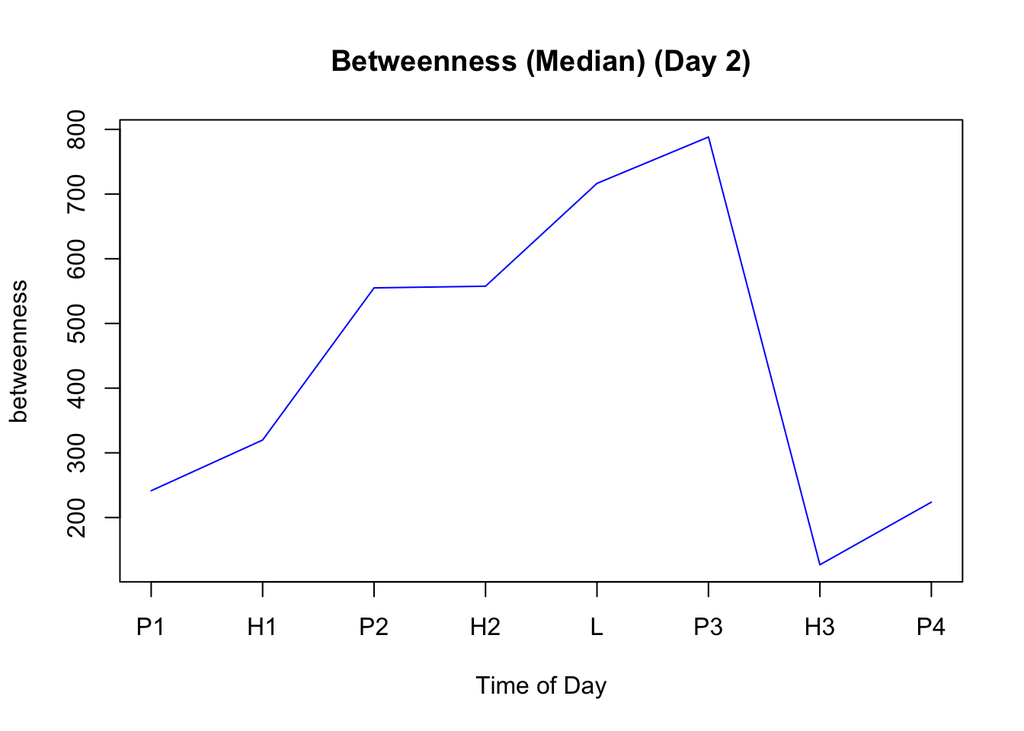

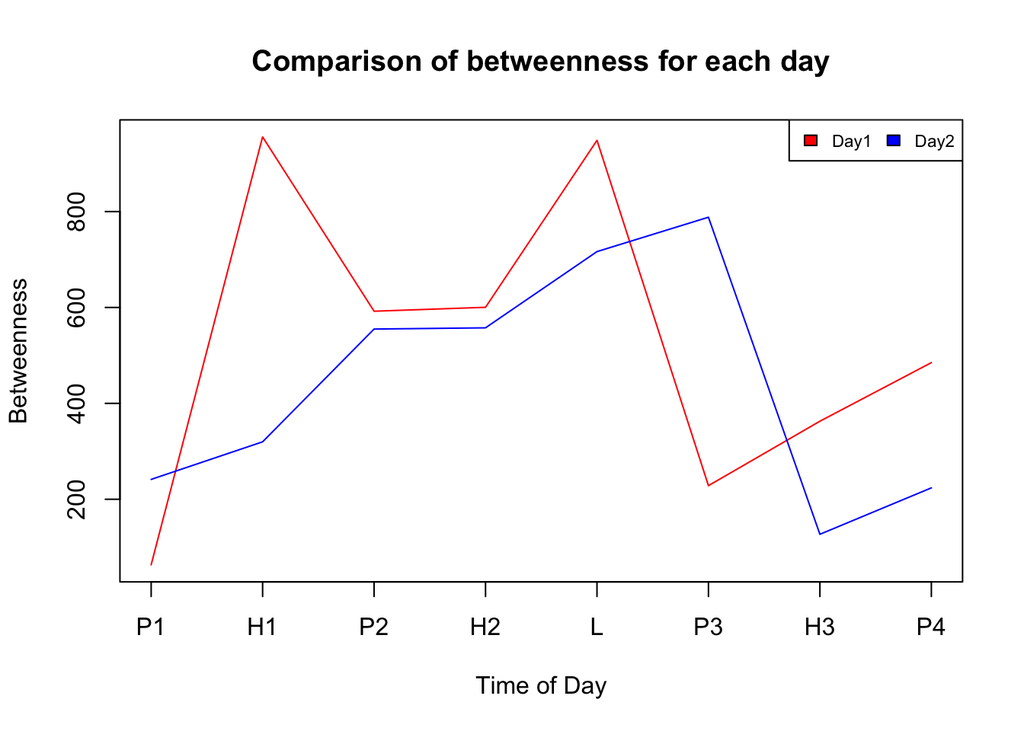

# Closeness

Day 1

```
##        Measure          Min           Q1       Median         Mean
## 1      All day 2.134016e-04 2.866972e-04 3.020236e-04 3.011528e-04
## 2  All periods 1.476233e-04 2.535497e-04 2.629503e-04 2.619763e-04
## 3     Period 1 4.928050e-07 3.702127e-06 3.722163e-06 3.312085e-06
## 4    Hallway 1 4.928050e-07 2.504182e-06 2.514199e-06 2.125963e-06
## 5     Period 2 4.928050e-07 4.610122e-06 4.641082e-06 4.222076e-06
## 6    Hallway 2 4.928050e-07 2.264559e-06 2.273203e-06 1.894226e-06
## 7        Lunch 4.928050e-07 8.053540e-06 8.090615e-06 7.643305e-06
## 8     Period 3 4.928050e-07 3.264667e-06 3.290903e-06 2.887783e-06
## 9    Hallway 3 4.928050e-07 4.931511e-07 1.774075e-06 1.423272e-06
## 10    Period 4 4.928050e-07 3.943482e-06 3.963221e-06 3.546797e-06
##              Q3          Max
## 1  3.165559e-04 3.526093e-04
## 2  2.718130e-04 3.082614e-04
## 3  3.736041e-06 3.765386e-06
## 4  2.518892e-06 2.526899e-06
## 5  4.661440e-06 4.705882e-06
## 6  2.277074e-06 2.285046e-06
## 7  8.115500e-06 8.179825e-06
## 8  3.303263e-06 3.326835e-06
## 9  1.776483e-06 1.780877e-06
## 10 3.976649e-06 4.004934e-06
```

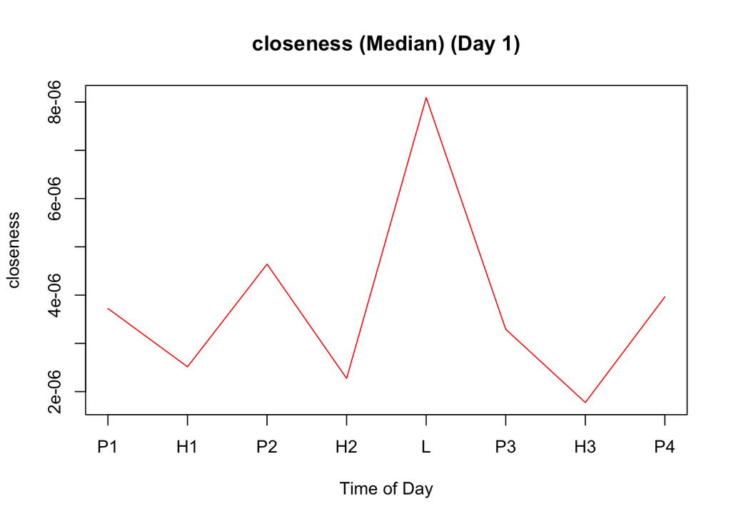

Day 2

```
##        Measure          Min           Q1       Median         Mean
## 1      All day 2.391772e-04 3.524850e-04 3.757280e-04 3.886689e-04
## 2  All periods 6.724136e-07 2.403846e-04 2.510040e-04 2.577183e-04
## 3     Period 1 6.724136e-07 3.654420e-06 3.677174e-06 3.143374e-06
## 4    Hallway 1 6.724136e-07 6.729652e-07 2.384381e-06 1.909823e-06
## 5     Period 2 6.724136e-07 7.073874e-06 7.125679e-06 6.544543e-06
## 6    Hallway 2 6.724136e-07 3.188793e-06 3.204353e-06 2.684412e-06
## 7        Lunch 6.724136e-07 4.451265e-06 4.471292e-06 3.917690e-06
## 8     Period 3 6.724136e-07 1.626076e-05 1.637774e-05 1.577242e-05
## 9    Hallway 3 6.724136e-07 6.729652e-07 2.083062e-06 1.634518e-06
## 10    Period 4 6.724136e-07 1.106960e-05 1.118374e-05 1.057664e-05
##              Q3          Max
## 1  4.314529e-04 4.791567e-04
## 2  2.797398e-04 2.998501e-04
## 3  3.686133e-06 3.709446e-06
## 4  2.388104e-06 2.394768e-06
## 5  7.156506e-06 7.235419e-06
## 6  3.210832e-06 3.221847e-06
## 7  4.482948e-06 4.510335e-06
## 8  1.647202e-05 1.669533e-05
## 9  2.086366e-06 2.090594e-06
## 10 1.130135e-05 1.135525e-05
```

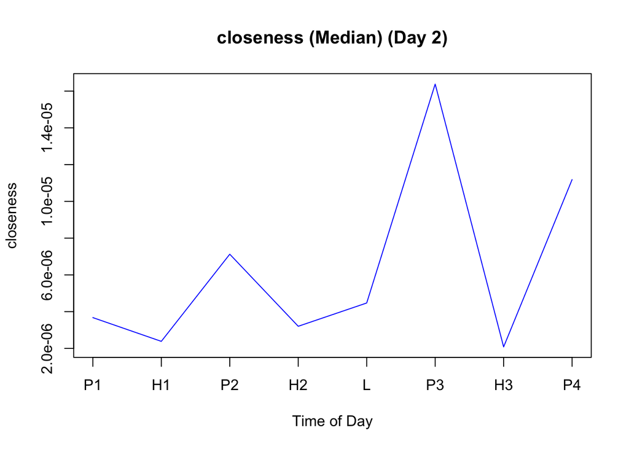

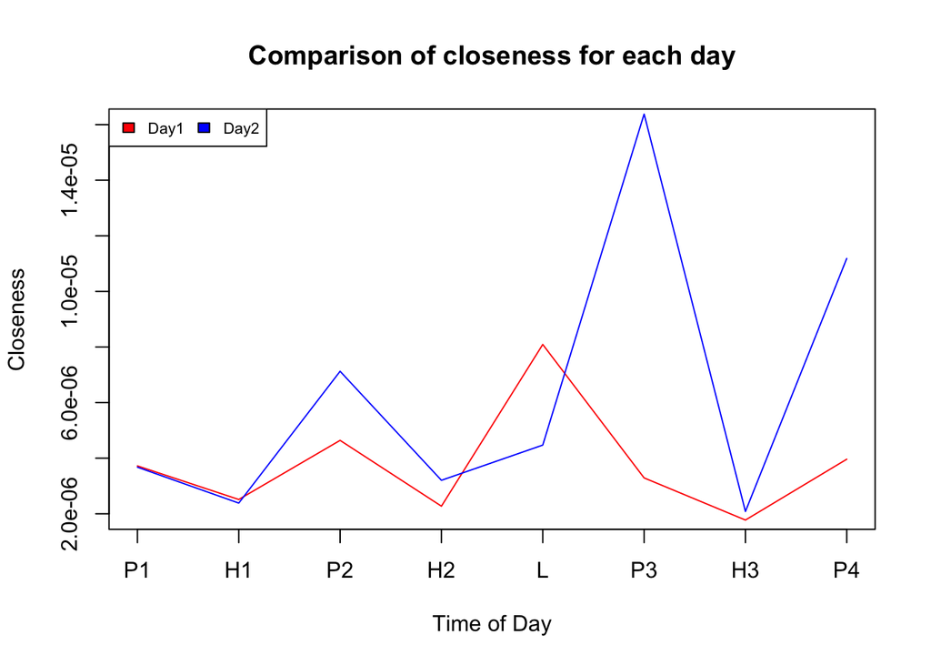

# Transitivity

```
##        Measure      Day1      Day2
## 1      All day 0.1823022 0.7506676
## 2  All periods 0.2978069 0.7779085
## 3     Period 1 0.7412191 0.4475851
## 4    Hallway 1 0.1046884 0.1498767
## 5     Period 2 0.4584243 0.4382355
## 6    Hallway 2 0.1176294 0.1198721
## 7        Lunch 0.1746072 0.2670097
## 8     Period 3 0.4913340 0.1891207
## 9    Hallway 3 0.1164544 0.1271959
## 10    Period 4 0.4473970 0.8846711
```

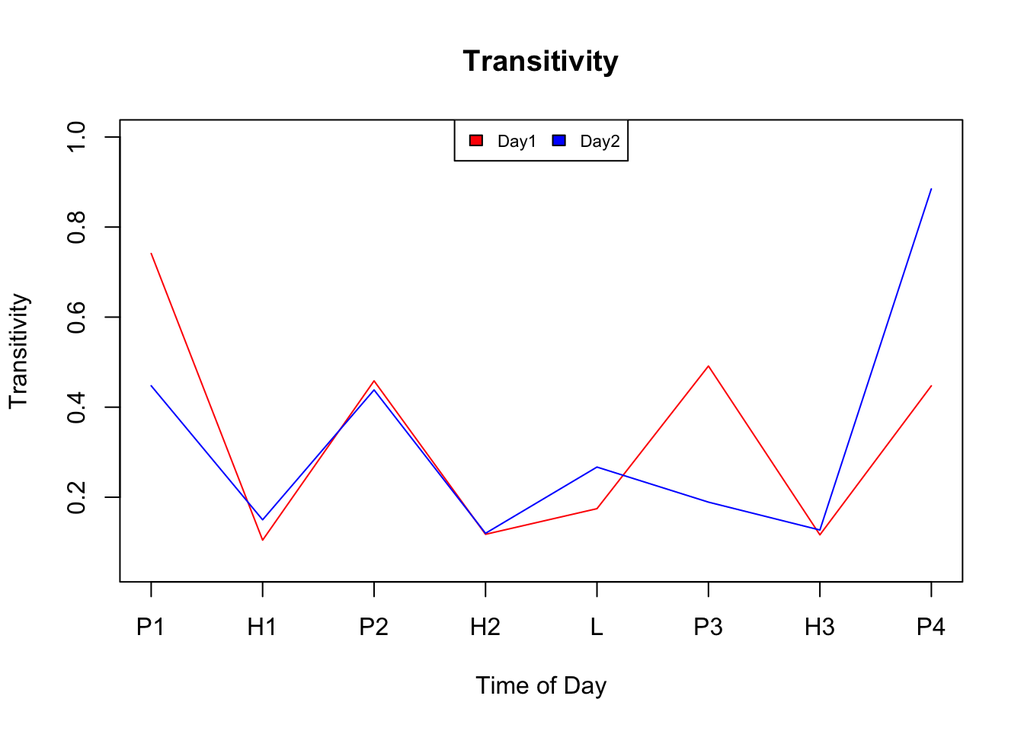

# Density

```
##        Measure        Day1        Day2
## 1      All day 0.151782969 0.748981293
## 2  All periods 0.114319929 0.731837437
## 3     Period 1 0.048514686 0.021584475
## 4    Hallway 1 0.002350680 0.002448930
## 5     Period 2 0.022613838 0.023106820
## 6    Hallway 2 0.002554701 0.003051413
## 7        Lunch 0.012764636 0.009138100
## 8     Period 3 0.020990538 0.027489611
## 9    Hallway 3 0.002283659 0.002505413
## 10    Period 4 0.022200867 0.650987776
```

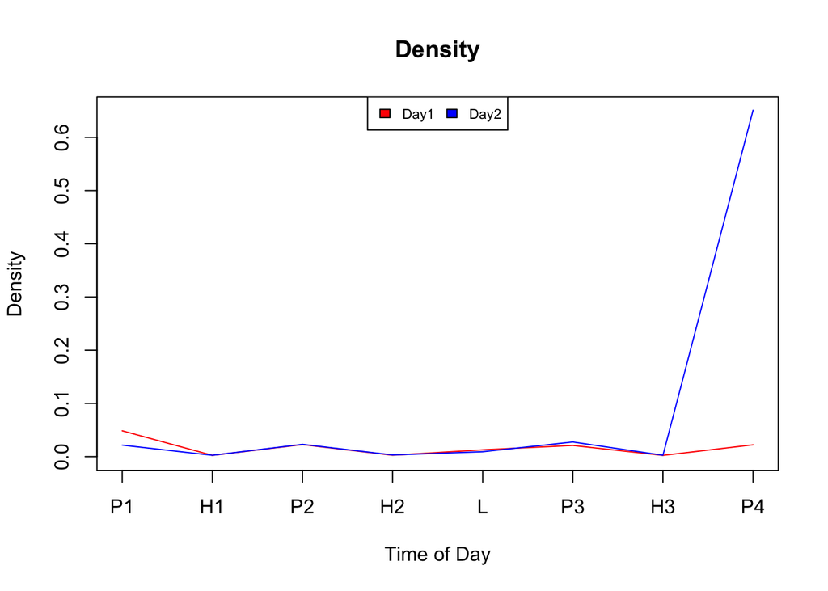

# Assortativity

I looked at 4 different reasons why a student would be more likely to interact with another student: if they were the same gender, in the same grade, had the same lunch, or interacted with the same number of students.

Day 1

```
##        Measure    Degree  GenderCat  GradeCat      Lunch
## 1      All day 0.1729348 0.18532409 0.6176091 0.24153951
## 2  All periods 0.2143047 0.14201952 0.6555558 0.20689575
## 3     Period 1 0.5945900 0.09155421 0.6569461 0.04336572
## 4    Hallway 1 0.1304607 0.19934872 0.5074168 0.02772307
## 5     Period 2 0.4325414 0.18705206 0.7125158 0.04444116
## 6    Hallway 2 0.3817808 0.24454924 0.5407445 0.29084927
## 7        Lunch 0.2531446 0.37082585 0.6014776 0.73191453
## 8     Period 3 0.4314996 0.15979813 0.6446122 0.96825876
## 9    Hallway 3 0.2166636 0.22722294 0.5509142 0.33554356
## 10    Period 4 0.4535261 0.18897755 0.5926358 0.03361289
```

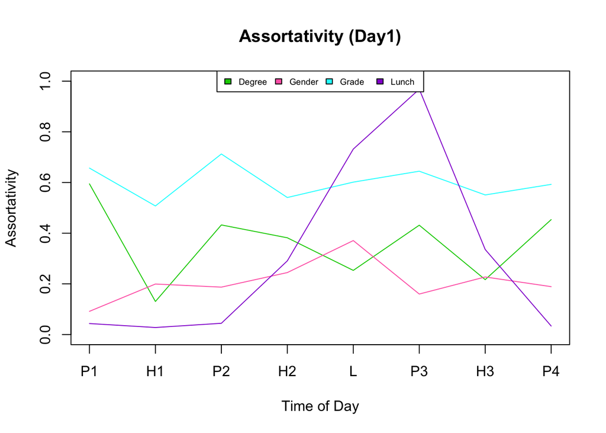

Day 2

```
##        Measure    Degree   GenderCat   GradeCat        Lunch
## 1      All day 0.5618487  0.02708553 0.09573177  0.048471248
## 2  All periods 0.5514066  0.02267020 0.08264291  0.039003851
## 3     Period 1 0.4586588  0.21416905 0.64510699  0.057504029
## 4    Hallway 1 0.2261451  0.23631466 0.55427274  0.081951891
## 5     Period 2 0.4948827  0.16602239 0.69864308  0.110788210
## 6    Hallway 2 0.4471911  0.16923223 0.49546541  0.182620132
## 7        Lunch 0.3293667  0.20039163 0.64233551  0.627094628
## 8     Period 3 0.3469509  0.24230235 0.64143490  0.961614982
## 9    Hallway 3 0.2310550  0.24723797 0.00000000  0.539674517
## 10    Period 4 0.4328890 -0.00210218 0.00000000 -0.002105876
```

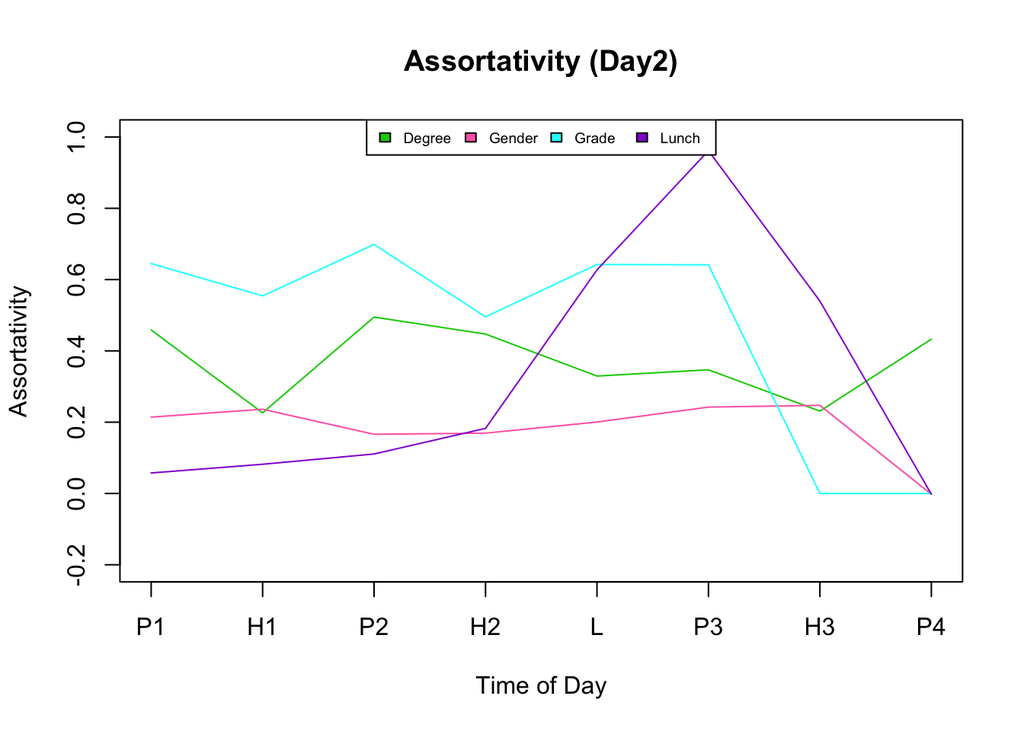

Comparing each characteristic:

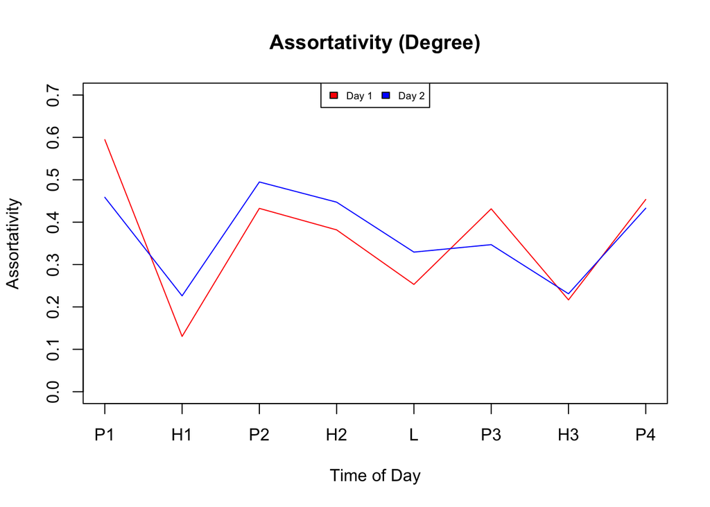

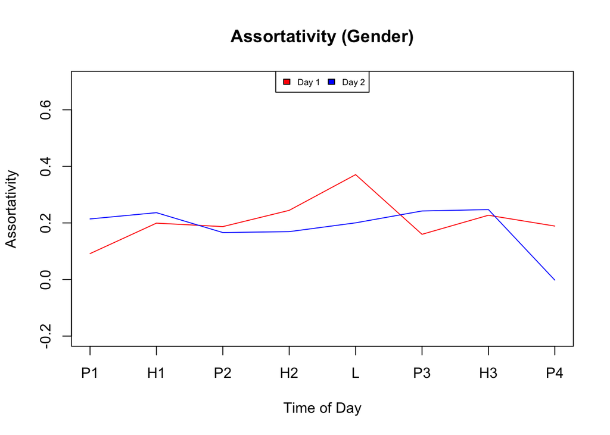

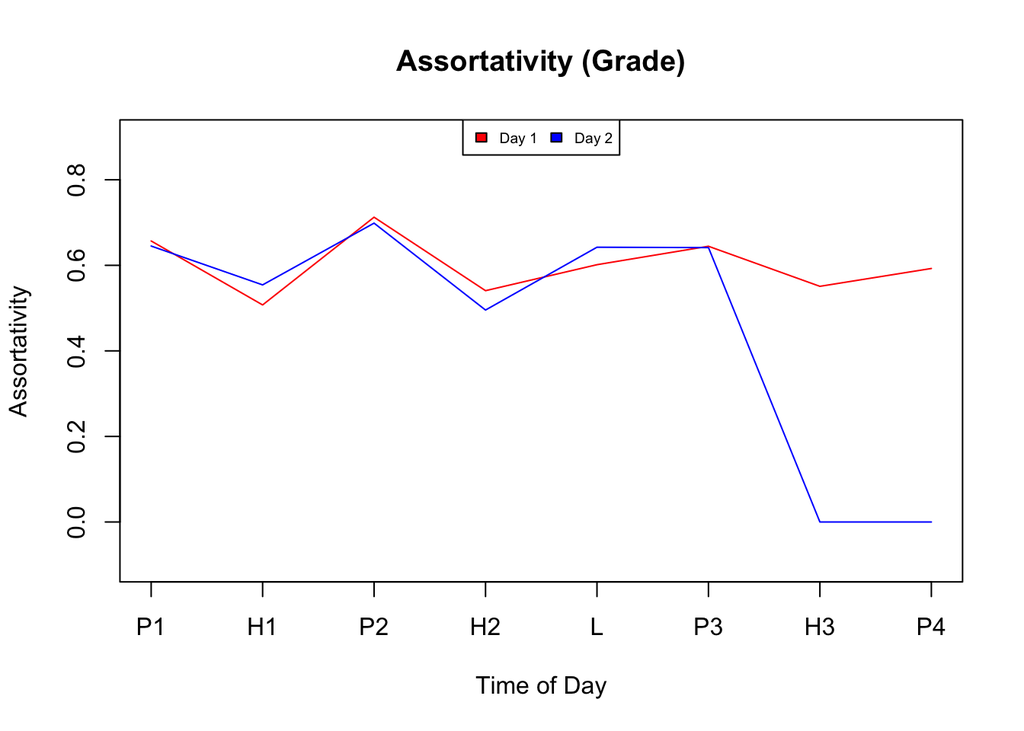

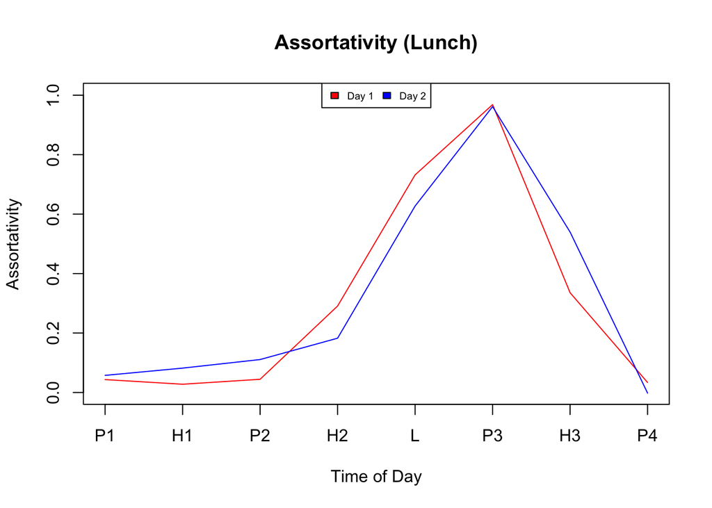